# Time Series Homework: Chapter 1 Lesson 5 Key

## Data

```r
vessels <- rio::import("https://byuistats.github.io/timeseries/data/Vessels_Trade_US.csv")
```

## Questions

### Question 1: Context and Measurement (10 points)

The first part of any time series analysis is context. You cannot properly analyze data without knowing what the data is measuring. Without context, the most simple features of data can be obscure and inscrutable. This homework assignment will center around the series below.

Please research the time series. In the spaces below, give the data collection process, unit of analysis, and meaning of each observation for the series.

#### a) **Vessels Cleared in Foreign Trade for United States**

https://fred.stlouisfed.org/series/M03022USM583NNBR

**Answer**

Data Collection: This data is a monthly summary of vessels cleared for foreign trade that are departing from the U.S to foreign destinations. Before the vessel can leave there are various checks including customs clearance, security checks and payment of duties and fees. During the cargo declaration, the details of the goods, such as origin, destination, description and importantly weight is recorded. This is when the number of tons per 100 cubic feet would be recorded.

Meaning of an Observation: The weight of foreign trade cleared in a single month recorded in net tons of 100 cubic feet.

### Question 2: Seasonally Adjusted Series - Calculation and Plot (10 points)

#### a) Decompose the Vessels Cleared in Foreign Trade series using the multiplicative decomposition model. Show the first 10 rows of results from the decomposition as shown in the Time Series Notebook.

**Answer**

```r
# Please provide your code here
vessel_tsibble <- vessels %>%
  mutate(date = dmy(date)) %>% #convert to date year month data type
  mutate(year_month = yearmonth(date)) %>% #extract the year and month
  as_tsibble(index = year_month) #make the year month the index of the timeseries

vessel_decomp <-  vessel_tsibble |>
  model(feasts::classical_decomposition(vessels,#decompose function to get out random, adjusted seasonal values and trend
                                        type = "mult"))  |>
  components() |>
  select(!.model)

head(vessel_decomp, 10)
```

```
# A tsibble: 10 x 6 [1M]
   year_month vessels trend seasonal random season_adjust
        <mth>   <int> <dbl>    <dbl>  <dbl>         <dbl>
 1   1901 Jan    2128   NA     0.794  NA            2679.
 2   1901 Feb    1983   NA     0.743  NA            2670.
 3   1901 Mar    2206   NA     0.834  NA            2645.
 4   1901 Apr    2362   NA     0.908  NA            2601.
 5   1901 May    2792   NA     1.05   NA            2666.
 6   1901 Jun    2742   NA     1.13   NA            2417.
 7   1901 Jul    3159 2606.    1.21    1.00         2612.
 8   1901 Aug    3291 2584.    1.23    1.03         2671.
 9   1901 Sep    2930 2556.    1.13    1.01         2587.
10   1901 Oct    2935 2545.    1.09    1.06         2687.
```

#### b) Illustrate the original, trend, and the seasonally adjusted series in the same plot. Use the appropriate axis labels, units, and captions.

**Answer**

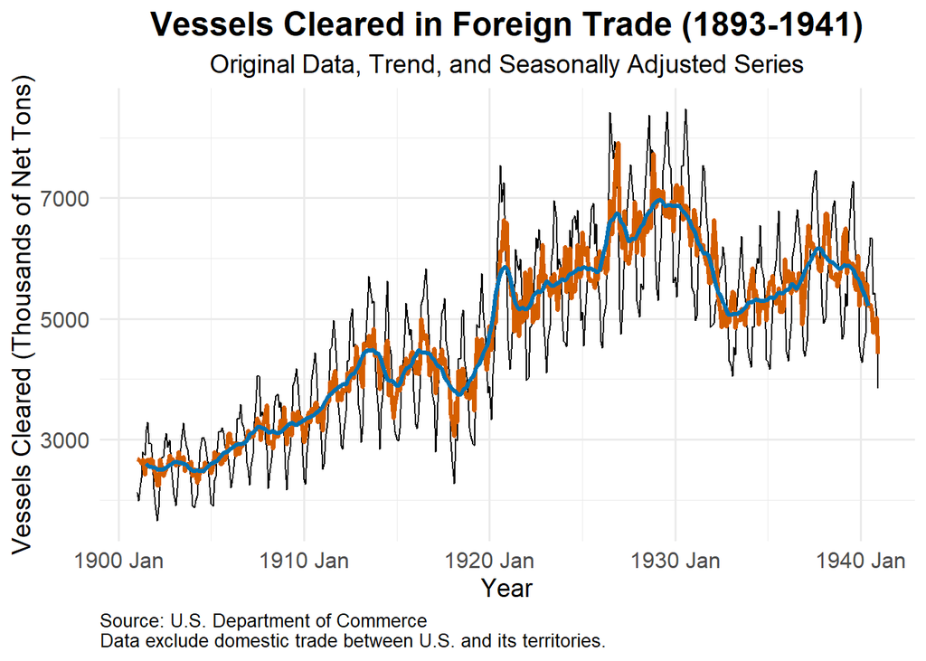

```r
# Please provide your code here
# Please provide your code here

ggplot(vessel_decomp) +
  geom_line(data = vessel_decomp, aes(x = year_month, y = vessels), color = "black") +
  geom_line(data = vessel_decomp, aes(x = year_month, y = season_adjust), color = "#D55E00", size = 1.1) +
  geom_line(data = vessel_decomp, aes(x = year_month, y = trend), color = "#0072B2", size = 1.1) +
  labs(
    x = "Year",
    y = "Vessels Cleared (Thousands of Net Tons)",
    title = "Vessels Cleared in Foreign Trade (1893-1941)",
    subtitle = "Original Data, Trend, and Seasonally Adjusted Series",
    caption = "Source: U.S. Department of Commerce\nData exclude domestic trade between U.S. and its territories."
  ) +
  theme_minimal(base_size = 12) +
  theme(
    plot.title = element_text(hjust = 0.5, size = 18, face = "bold"),
    plot.subtitle = element_text(hjust = 0.5, size = 14),
    axis.title = element_text(size = 14),
    axis.text = element_text(size = 12),
    legend.title = element_blank(),
    legend.position = "bottom",
    legend.text = element_text(size = 12),
    plot.caption = element_text(hjust = 0, size = 10)
  ) +
  guides(color = guide_legend(override.aes = list(size = 2)))
```

### Question 3: Seasonally Adjusted Series - Analysis (30 points)

#### a) Plot the random component of the multiplicative decomposition from Q2a.

**Answer**

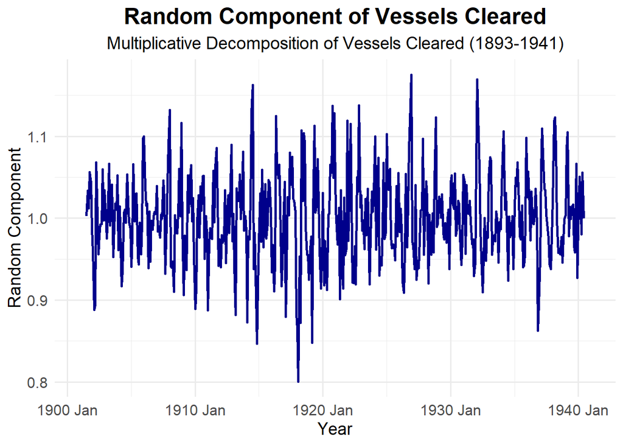

```r
# Please provide your code here
vessel_random <- vessel_decomp %>%
  select(year_month, random)

# Plot the random component using ggplot2
ggplot(vessel_random, aes(x = year_month, y = random)) +
  geom_line(color = "darkblue", size = 1) +
  labs(
    x = "Year",
    y = "Random Component",
    title = "Random Component of Vessels Cleared",
    subtitle = "Multiplicative Decomposition of Vessels Cleared (1893-1941)"
  ) +
  theme_minimal(base_size = 12) +
  theme(
    plot.title = element_text(hjust = 0.5, size = 18, face = "bold"),
    plot.subtitle = element_text(hjust = 0.5, size = 14),
    axis.title = element_text(size = 14),
    axis.text = element_text(size = 12)
  ) #plot this random component
```

#### b) Use the additive decomposition method to decompose the Vessels Cleared in Foreign Trade series. Plot the random component.

**Answer**

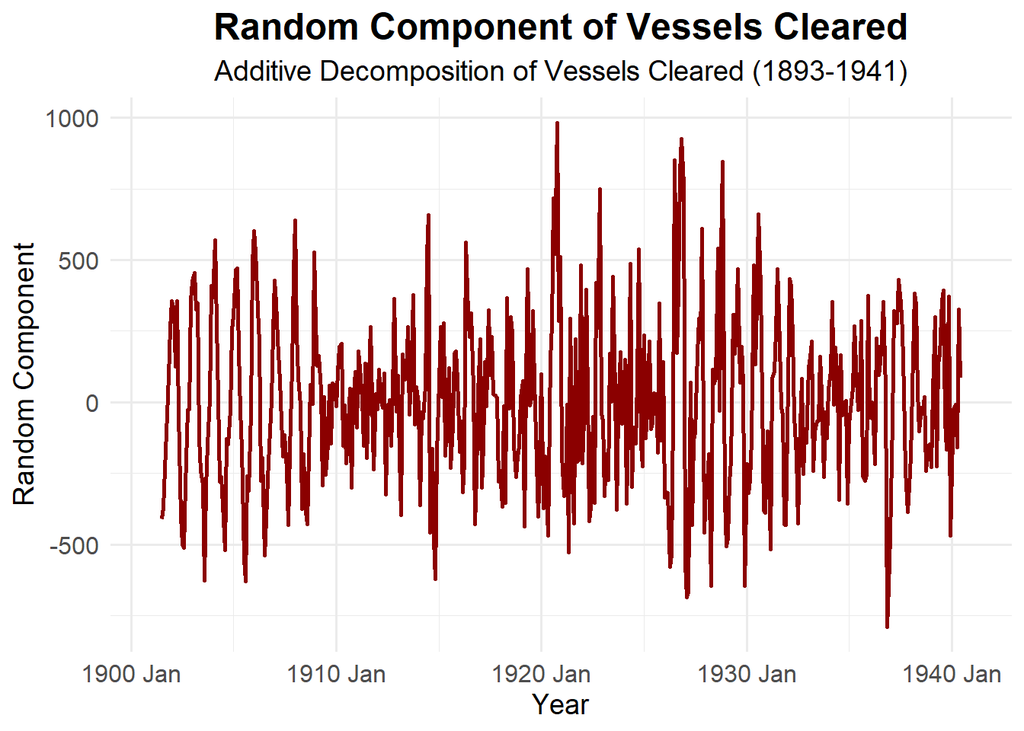

```r
# Please provide your code here
vessel_decomp_additive <- vessel_tsibble %>%
  model(classical_decomposition(vessels, type = "add")) %>%
  components()

vessel_random <- vessel_decomp_additive %>%
  select(year_month, random)

# Plot the random component using ggplot2
ggplot(vessel_random, aes(x = year_month, y = random)) +
  geom_line(color = "darkred", size = 1) +
  labs(
    x = "Year",
    y = "Random Component",
    title = "Random Component of Vessels Cleared",
    subtitle = "Additive Decomposition of Vessels Cleared (1893-1941)"
  ) +
  theme_minimal(base_size = 12) +
  theme(
    plot.title = element_text(hjust = 0.5, size = 18, face = "bold"),
    plot.subtitle = element_text(hjust = 0.5, size = 14),
    axis.title = element_text(size = 14),
    axis.text = element_text(size = 12)
  )
```

#### c) Please describe the differences between the random component series and use it as part of your justification for why we use the multiplicative decomposition model instead of the additive model to seasonally adjust the series.

**Answer**

Differences in Random Component Series:

Multiplicative Error: The error term in the multiplicative model fluctuates around 1. Crucially, the magnitude of the fluctuations appears relatively constant over time.

Justification for Multiplicative Decomposition:

The key observation is the changing variance in the additive error term. This indicates that the seasonal fluctuations in the original data are not constant in magnitude but rather grow or shrink proportionally to the level of the series itself.

Looking at the original series, the vessel traffic increases significantly over time. Simultaneously, the seasonal swings become more pronounced. This pattern directly corresponds to a multiplicative relationship: larger traffic values lead to larger seasonal variations.

An additive model assumes constant seasonal effects regardless of the level of the series. This is clearly violated in this case. If we were to use an additive model, we would likely under-adjust for seasonality in the later periods of high traffic and over-adjust in the early periods of low traffic.

In summary: The multiplicative decomposition model is preferred because the changing variance in the additive model’s error term indicates a non-constant seasonal effect. The multiplicative model, where seasonality is proportional to the level of the series, better captures the observed pattern of increasing seasonal fluctuations alongside increasing traffic levels in the original data. This proportionality is visually confirmed by both the error components plot and the original data plot. A multiplicative model will lead to a more accurate seasonally adjusted series in this situation.

## Rubric

[output not shown]